# COMPSCIX 415.2 Homework 6

## Exercise 2

#### 1. Generate a random sample of size n = 10000 from a gamma(1,2) distribution and plot a histogram or density curve. Use the code below to help you get your sample.

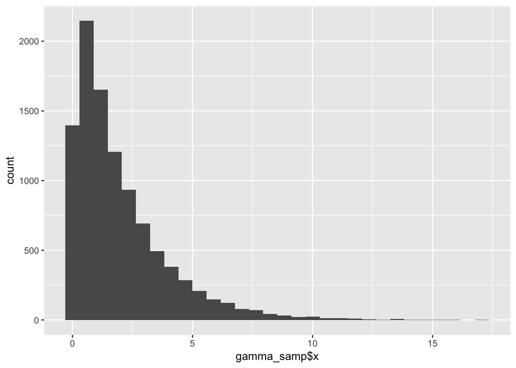

```r
n = 10000
gamma_samp <- tibble(x = rgamma(n, shape = 1, scale = 2))
ggplot() + geom_histogram(aes(x = gamma_samp$x))
```

#### 2. What is the mean and standard deviation of your sample?

```r
mean_samp <- gamma_samp %>% .[['x']] %>% mean()
sd_samp <- gamma_samp %>% .[['x']] %>% sd()
mean_samp
```

```
## [1] 1.997257
```

```r
sd_samp
```

```
## [1] 1.995548
```

#### 3. Pretend the distribution of our population of data looks like the plot above. Now take a sample of size n = 30 from a Gamma(1,2) distribution, plot the histogram or density curve, and calculate the mean and standard deviation.

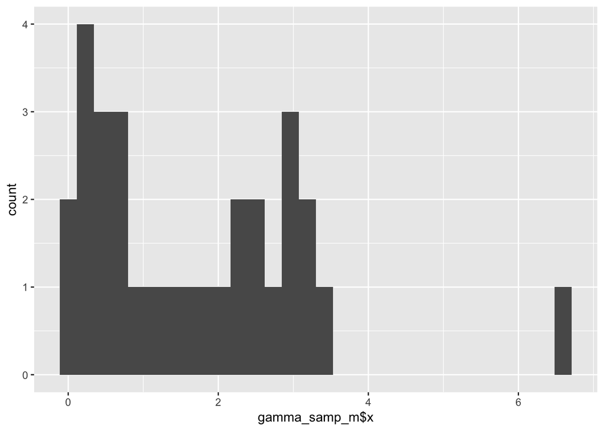

```r
m = 30
gamma_samp_m <- tibble(x = rgamma(m, shape = 1, scale = 2))
ggplot() + geom_histogram(aes(x = gamma_samp_m$x))
```

```r
mean_samp_m <- gamma_samp_m %>% .[['x']] %>% mean()
sd_samp_m <- gamma_samp_m %>% .[['x']] %>% sd()
mean_samp_m
```

```
## [1] 1.71484
```

```r
sd_samp_m
```

```
## [1] 1.46888
```

#### 4. Take a sample of size n = 30, again from the Gamma(1,2) distribution, calculate the mean, and assign it to a vector named mean_samp. Repeat this 10000 times!!!! The code below might help.

```r
mean_samp <- rep(NA, 10000)
for(i in 1:10000) {
  g_samp <- rgamma(30, shape = 1, scale = 2)
  mean_samp[i] <- mean(g_samp)
}
mean_samp <- tibble(mean_samp)
mean_samp
```

```
## # A tibble: 10,000 x 1
##    mean_samp
##        <dbl>
##  1      1.86
##  2      1.56
##  3      1.53
##  4      1.69
##  5      2.26
##  6      2.35
##  7      2.26
##  8      2.09
##  9      1.94
## 10      1.92
## # … with 9,990 more rows
```